# Orthotopic Model CUP0006

Leyla Azarang and Renee Menezes

2024-04-11

```r
source("./scripts/mysplit.R")
source("./scripts/functions_data_centre_ortho.R")
```

## Read in data

First read in information about centres available for this model.

```r
xi <- 2
alldata <- readxl::read_excel("./data/overview1.xlsx")
myfile <- alldata$FileName[xi]
mymodel <- strsplit(myfile, split = " ")[[1]][ 1 ]
all.sheets <- as.character(alldata[xi, -1])
names(all.sheets) <- colnames(alldata)[ -1 ]
all.sheets <- all.sheets[ !is.na(all.sheets) ]
list.centers <- names(all.sheets)
```

The data here is for model CUP0006_orthotopic.xlsx. It was analysed by the following centers:

```r
knitr::kable(list.centers, col.names = "Centers")
```

| Centers |
| --- |
| VHIO |
| RCSI |
| RUG |

### Analysis per center

Reading the data per center.

```r
n_centers <- length(list.centers)

data_centers <- lapply(1:n_centers, read_sheet, myfile = myfile,
                       all.sheets = all.sheets)
names(data_centers) <- list.centers
```

```r
names(data_centers[[2]])
```

```
##  [1] "Genealogy ID"   "Barcode"        "Group"          "Label"
##  [5] "Treatment"      "Start Info"     "End Info"       "44678"
##  [9] "44704"          "44711"          "44733"          "44753"
## [13] "follow up time"
```

```r
as.Date(as.numeric( names(data_centers[[2]])[9:12]), origin = "1899-12-30")
```

```
## [1] "2022-05-23" "2022-05-30" "2022-06-21" "2022-07-11"
```

Extract treatment, start and end dates from Label column. For this batch of analyses the event variable is not consistently recorded across all data files.

The data is currently in the wide format, and for the analyses we need it in the long format (one observation per row, for one individual at a time).

```r
all_data_long <- lapply(1:n_centers, get_data_long, mydatac = data_centers)
names(all_data_long) <- list.centers
```

We now need to leave out measurements before the start of the treatment, and after ending it.

```r
data_long_treat <- lapply(1:n_centers, get_vol_treat, alldata = all_data_long)
names(data_long_treat) <- names(all_data_long)
```

## Exploratory data analysis

The following plots depict the tumor volume growth per each center, for each model separately.

```r
vp <- lapply(1:n_centers, function(xc){
p <-  ggplot(data = data_long_treat[[ xc ]], aes(x = days, y = volume,
                                             group = `GenealogyID`, color =Treatment)) +
    geom_line()+
    geom_point(aes(x = days, y = volume))+
    facet_wrap( vars( `GenealogyID`)  )+
    ylab("tumor volume")+
    theme(legend.position = "top") +
    ggtitle(paste(names(data_long_treat)[xc]) )
return(p)
}
)
```

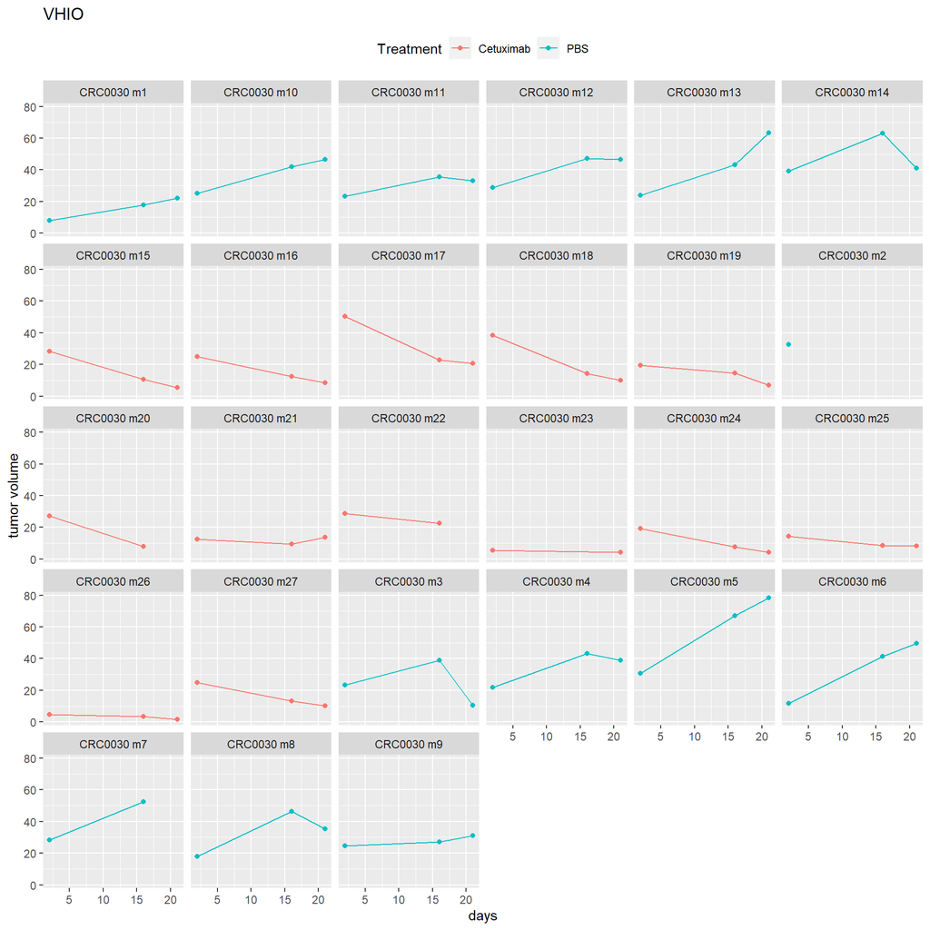

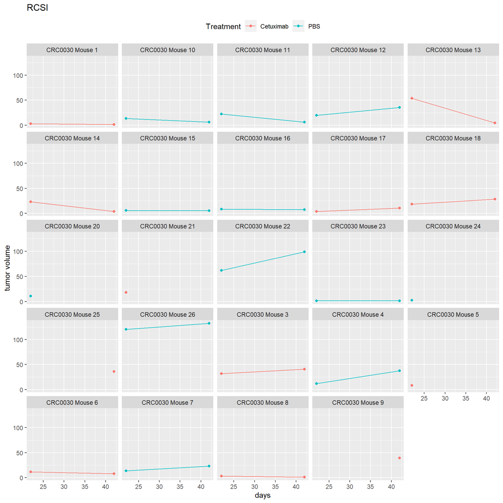

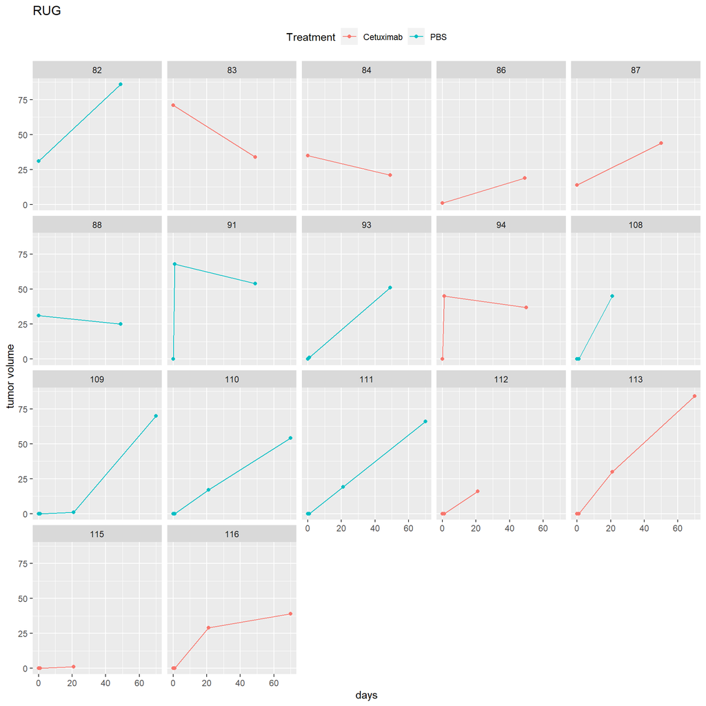

```r
vp
```

Now group all curves per treatment.

```r
vp <- lapply(1:n_centers, function(xc){
p <-  ggplot(data = data_long_treat[[ xc ]], aes(x = days, y = volume,
                                             group = GenealogyID, color = Treatment)) +
    geom_line()+
     geom_point(aes(x = days, y = volume))+
    facet_wrap( vars( `Treatment`)  )+
    ylab("tumor volume")+
    theme(legend.position = "top") +
    ggtitle(paste(names(data_long_treat)[xc]) )
return(p)
}
)
```

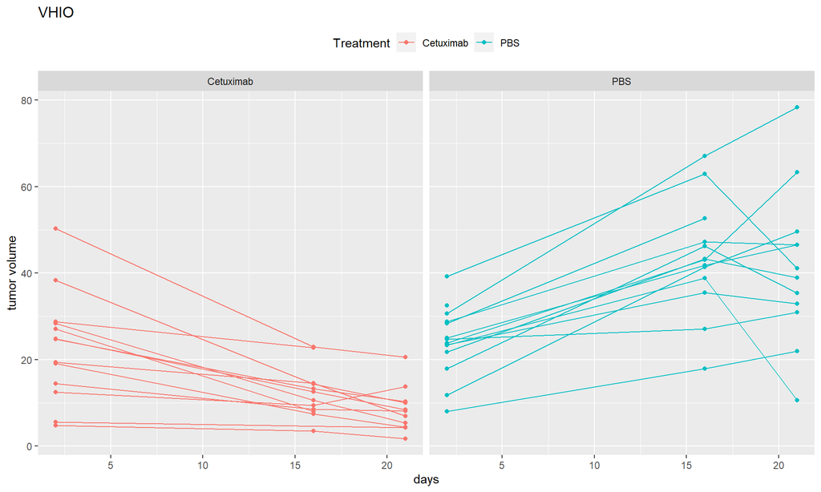

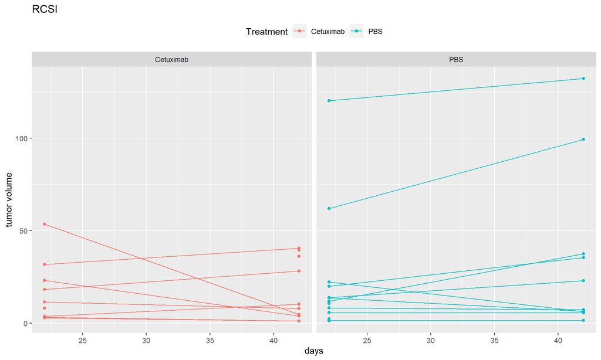

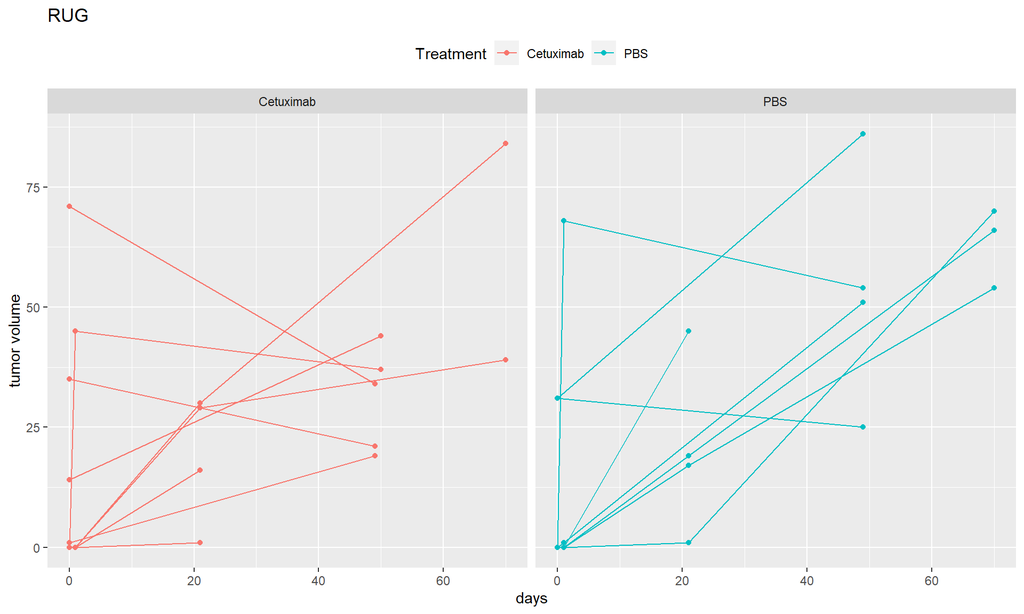

```r
vp
```

## The impact of center on tumor growth

In this section we investigate the effect of center on tumor growth in each treatment level. For this, we put all data together into a single data frame.

```r
all_data <- NULL
for(xc in 1:(n_centers)) # we exclude RUG because of not having longitudinal data
{
  datac <- data_long_treat[[ xc ]]
  datac$center <- rep(list.centers[ xc ], nrow(datac))
  all_data <- rbind(all_data, datac)
}
all_data <- all_data[!is.na(all_data$volume), ]
```

### The effect of treatment per center

```r
cont <- nlmeControl( maxIter = 100000, msMaxIter = 1000, tolerance = 1e-6, niterEM = 10000, msMaxEval = 10000)

all_fits <- lapply(1:(n_centers), function(xc){
      lme_fit <- lme(volume ~   days +  days:Treatment, data = data_long_treat[[xc]],
                     random = ~ days | GenealogyID, control = cont)
      mysumm <- summary(lme_fit)
      pval= summary(lme_fit)$tTable["days:TreatmentPBS", "p-value"]
      mfitted <- fitted(lme_fit, level =0)
      res_fitted <- tibble( GenealogyID = names(mfitted),
                           Treatment = data_long_treat[[ xc ]]$Treatment,
                            days = data_long_treat[[ xc ]]$days, fit_fix = mfitted)

      return(list( lme_fit= lme_fit , fit_sum = mysumm , fit_tibble = res_fitted , pv= pval  ) )
}
)

list_lme_fit <- lapply(1:(n_centers) , function(xc){return(all_fits[[xc]][[1]])})
names(list_lme_fit) <- names(data_long_treat)[1:3]

list_lme_summ <- lapply(1:(n_centers) , function(xc){return(all_fits[[xc]][[2]])})
names(list_lme_summ) <- names(data_long_treat)[1:3]

list_lme_fitted <- lapply(1:(n_centers) , function(xc){return(all_fits[[xc]][[3]])})
names(list_lme_fitted) <- names(data_long_treat)[1:3]

pvals <- round( sapply(1:(n_centers) , function(xc){return(all_fits[[xc]][[4]])}), 3)
```

Print each model fit summary.

```r
list_lme_summ
```

```
## $VHIO
## Linear mixed-effects model fit by REML
##   Data: data_long_treat[[xc]]
##        AIC      BIC    logLik
##   570.4644 586.4011 -278.2322
##
## Random effects:
##  Formula: ~days | GenealogyID
##  Structure: General positive-definite, Log-Cholesky parametrization
##             StdDev    Corr
## (Intercept) 8.2306518 (Intr)
## days        0.4592062 -0.324
## Residual    6.8133837
##
## Fixed effects:  volume ~ days + days:Treatment
##                       Value Std.Error DF   t-value p-value
## (Intercept)       23.619914 2.1452751 46 11.010203   0e+00
## days              -0.723931 0.1739572 46 -4.161547   1e-04
## days:TreatmentPBS  1.763909 0.2189048 46  8.057882   0e+00
##  Correlation:
##                   (Intr) days
## days              -0.441
## days:TreatmentPBS -0.001 -0.640
##
## Standardized Within-Group Residuals:
##         Min          Q1         Med          Q3         Max
## -2.63175784 -0.39862895 -0.04755105  0.39007791  2.18956100
##
## Number of Observations: 75
## Number of Groups: 27
##
## $RCSI
## Linear mixed-effects model fit by REML
##   Data: data_long_treat[[xc]]
##        AIC      BIC    logLik
##   388.1449 399.7898 -187.0724
##
## Random effects:
##  Formula: ~days | GenealogyID
##  Structure: General positive-definite, Log-Cholesky parametrization
```

[output cut: 37 more lines]

```
##                       Value Std.Error DF  t-value p-value
## (Intercept)       11.572824  4.376243 31 2.644465  0.0127
## days               0.503261  0.150711 31 3.339250  0.0022
## days:TreatmentPBS  0.262761  0.169545 31 1.549800  0.1313
##  Correlation:
##                   (Intr) days
## days              -0.591
## days:TreatmentPBS  0.012 -0.586
##
## Standardized Within-Group Residuals:
##        Min         Q1        Med         Q3        Max
## -1.4625646 -0.4405684 -0.2412233  0.2076330  2.6862692
##
## Number of Observations: 50
## Number of Groups: 17
```

The following plots depict the tumor volume increase in each center for both treatment groups.

```r
vp <- lapply(1:(n_centers), function(xc){

p <- ggplot(data = list_lme_fitted[[xc]], aes(x = days, y = fit_fix))+
  geom_line(aes(color=Treatment))+
  ylab("tumor volume")+
    xlim(0,60) +
  ggtitle(paste(names(data_long_treat)[xc]) )+
     annotate("text", x = 25, y = 100, label = paste("p-value:", pvals[[xc]]) )
return(p)
}
)
```

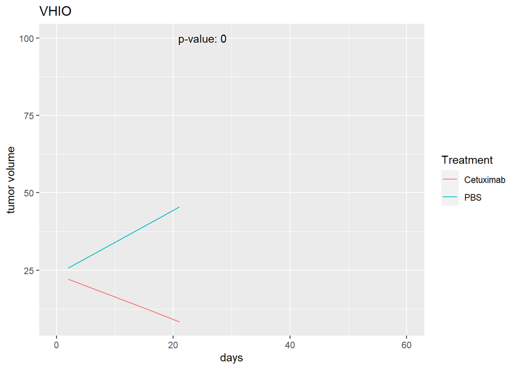

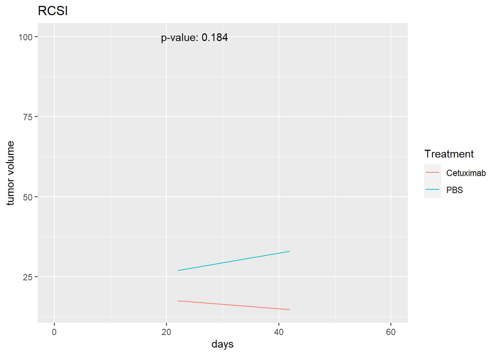

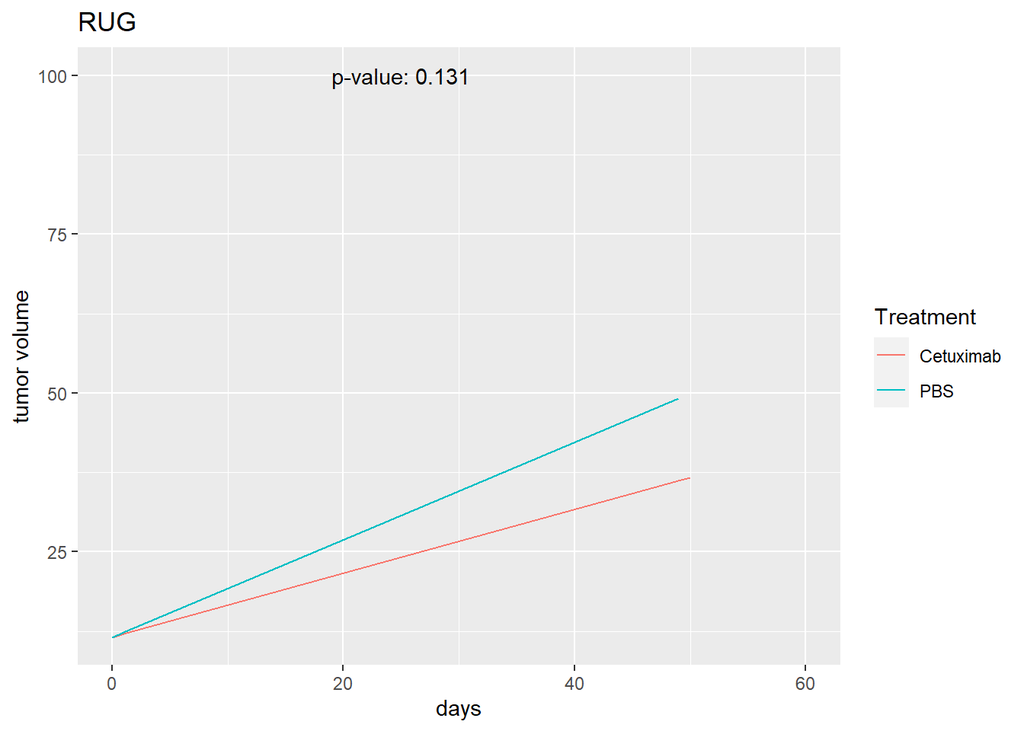

```r
vp
```

## Conclusion

By taking tumor volume data into consideration, we observe that at both “VHIO” and “RCSI” tumor volume decreases in treatment group whereas in vehicle group it increases over time. But, at RCSI this difference is not significant, it might be because there are a few mice for those tumor volumes were observed for few time points.

Not to mention that for orthotopic models we do not have information about the event (cause of death, etc), hence we were not able to do the joint model analyses using both survival and tumor volume data.